# TSDZPart2

Kate Bakshinskaia

4 апреля 2019 г

# SSA на модельных данных (ряды с номерами 1 и 7)

```r
data1 <- read_excel('D:/Учеба/1 КУРС МАГИСТРАТУРА/Голяндина практика/stud2005.xls')
data1 <- data1[,c(1,7)]
data1
```

```
## # A tibble: 1,000 x 2
##       COL1  COL7
##      <dbl> <dbl>
##  1  0.0560  399.
##  2  3.91    401.
##  3  6.46    404.
##  4  8.21    407.
##  5  8.47    407.
##  6 11.1     410.
##  7 12.1     411.
##  8 14.8     412.
##  9 16.8     413.
## 10 18.8     414.
## # ... with 990 more rows
```

## Ряд 1

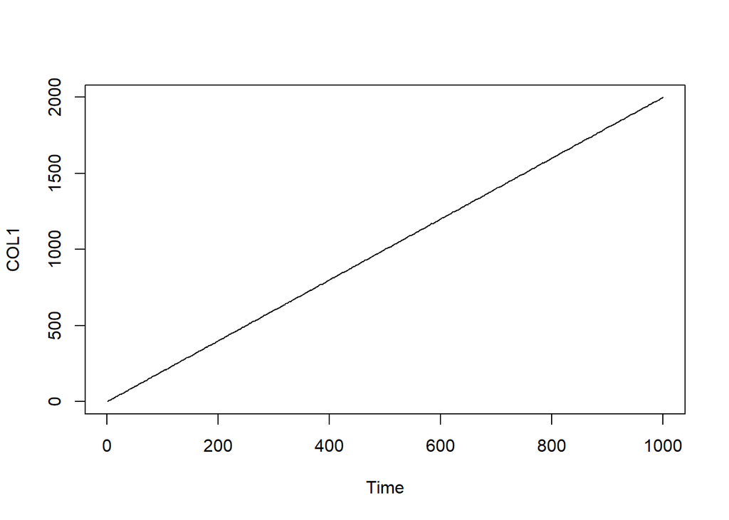

```r
Mod1 <- data1[,1]
plot.ts(Mod1)
```

Периодограмма:

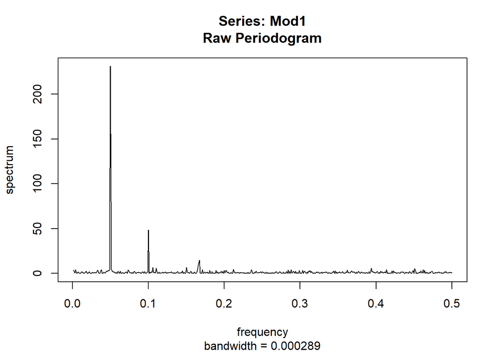

```r
spec.pgram(Mod1, detrend="TRUE",  log = "no",  plot = TRUE)
```

пик в 0.1 и явный в 0.05

ВФДЕЛЕНИЕ ТРЕНДА

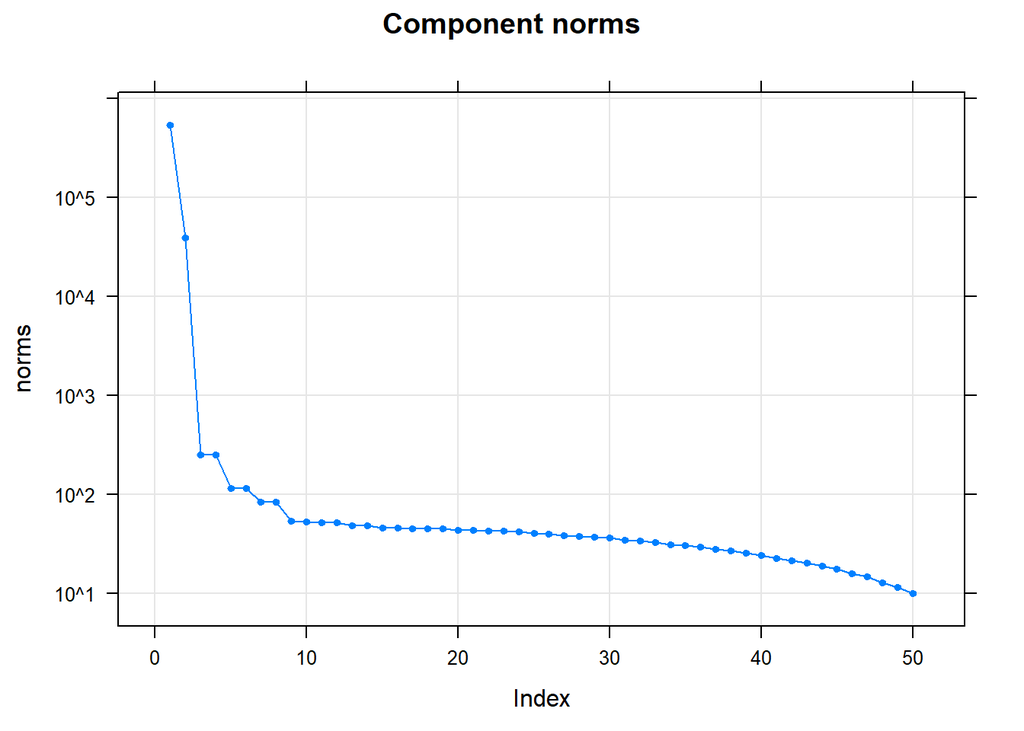

```r
s <- ssa(Mod1)
plot(s) #с.ч.
```

Посмотрим на график собственных векторов:

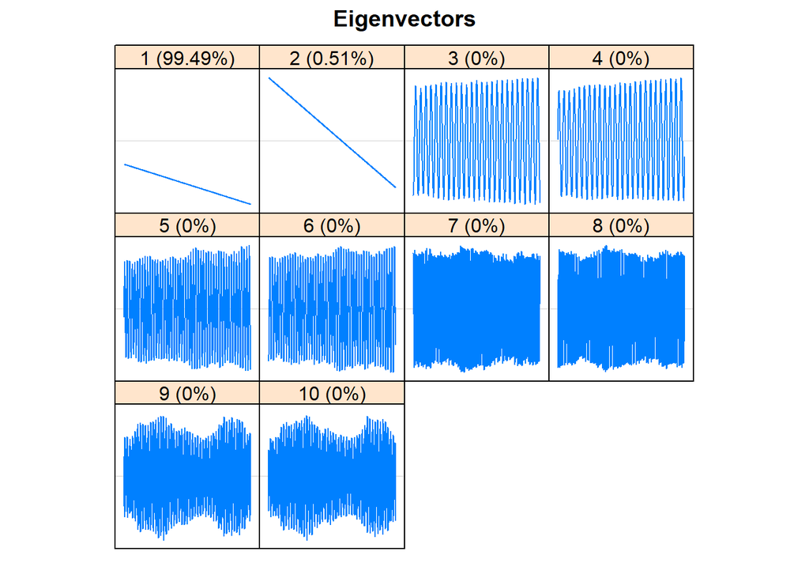

```r
plot(s, type = "vectors")
```

2 медленно меняющие состовляющие 1 и 2я

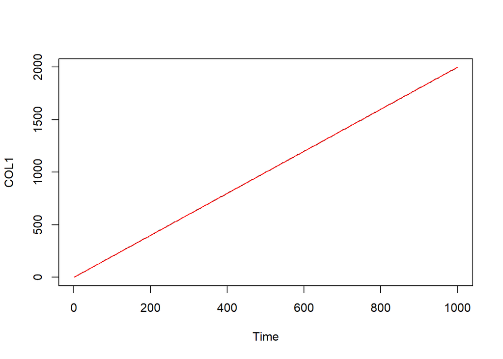

```r
trendrec <- reconstruct(s, group = list(trend = c(1,2)))

plot(ts(Mod1), col="black")
lines(trendrec$trend ,col="red")
```

Супер! Теперь остаток после тренда разделим на периодическую составляющую и шум.

ВЫДЕЛЕНИЕ ПЕРИОДИЧНОСТИ

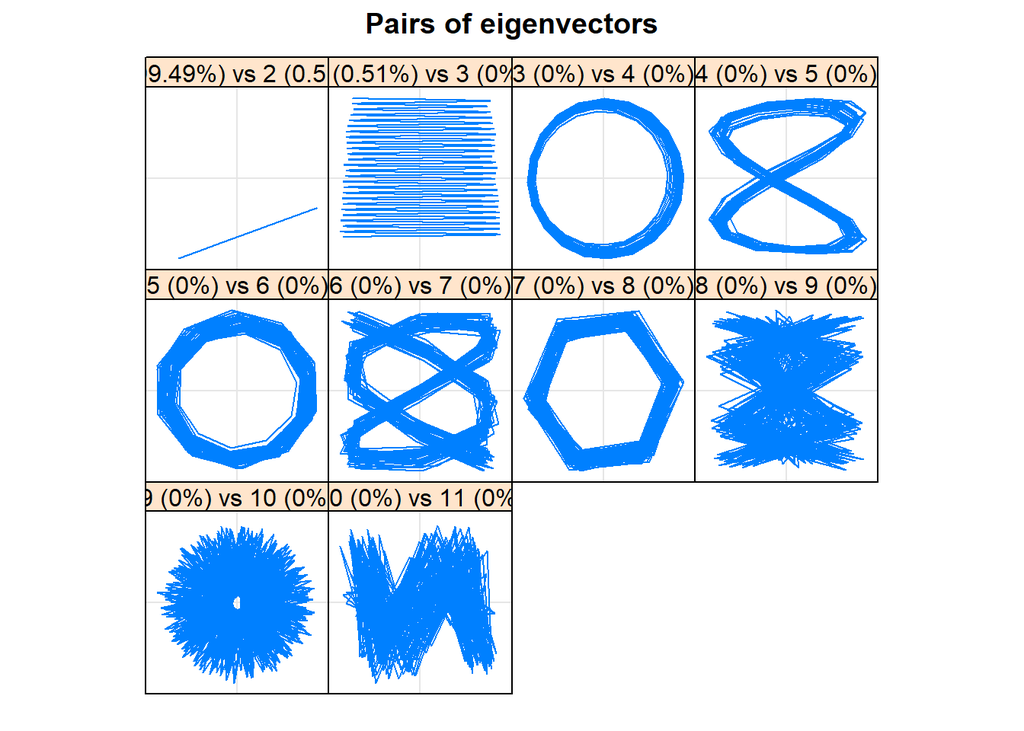

```r
plot(s, type = "paired")
```

Посмотрев на эти графики, к сезонности попробуем отнести 3:4, 5:6, 7:8

```r
pe <- parestimate(s, groups = list(3:4, 5:6, 7:8))
pe
```

```
## $F1
##    period     rate   |    Mod     Arg  |     Re        Im
##    20.005   0.000269 |  1.00027   0.31 |  0.95134   0.30902
##   -20.005   0.000269 |  1.00027  -0.31 |  0.95134  -0.30902
##
## $F2
##    period     rate   |    Mod     Arg  |     Re        Im
##    10.006   0.000250 |  1.00025   0.63 |  0.80943   0.58764
##   -10.006   0.000250 |  1.00025  -0.63 |  0.80943  -0.58764
##
## $F3
##    period     rate   |    Mod     Arg  |     Re        Im
##     6.000  -0.000482 |  0.99952   1.05 |  0.49977   0.86560
##    -6.000  -0.000482 |  0.99952  -1.05 |  0.49977  -0.86560
```

Mатрицa w-корреляций:

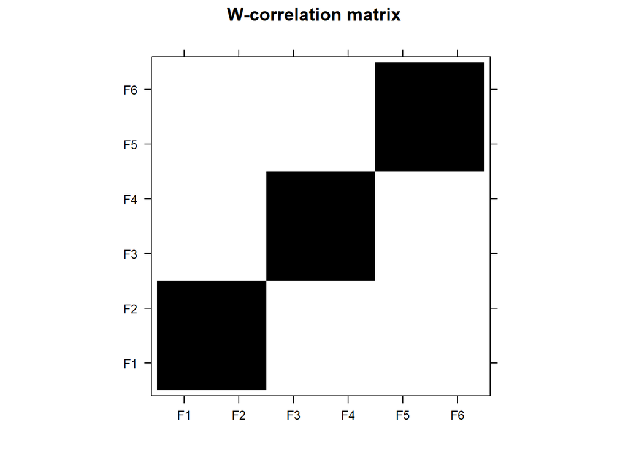

```r
sesrec <- reconstruct(s, groups = list( season =c(3:4, 5:6, 7:8)))

plot(wcor(s, groups = c(3:4, 5:6, 7:8)))
```

Шум:

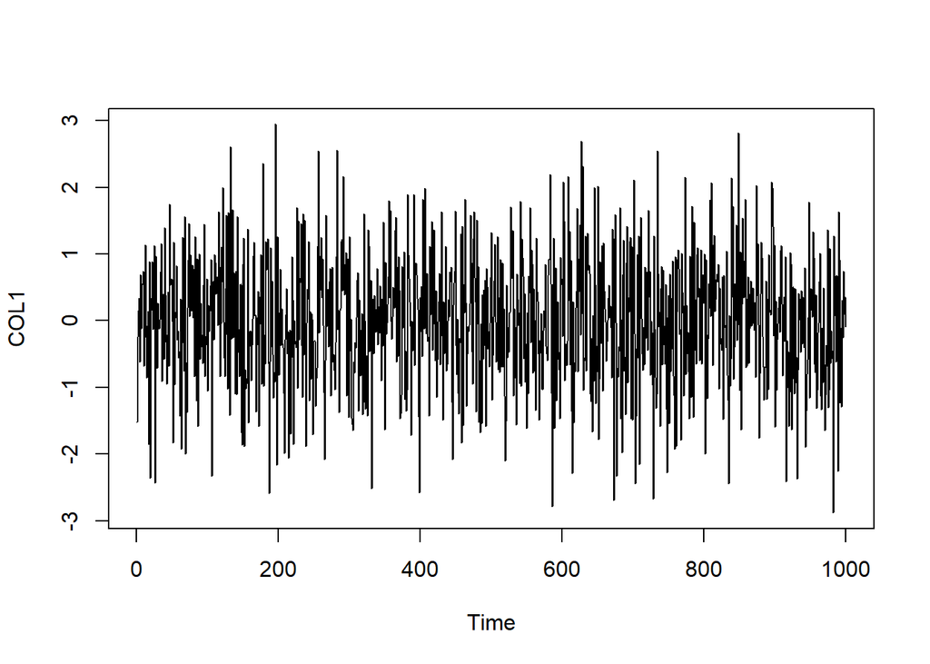

```r
OST <- Mod1 - trendrec$trend - sesrec$season
plot(ts(OST))
```

Анализ шума:

Периодограмма остатка:

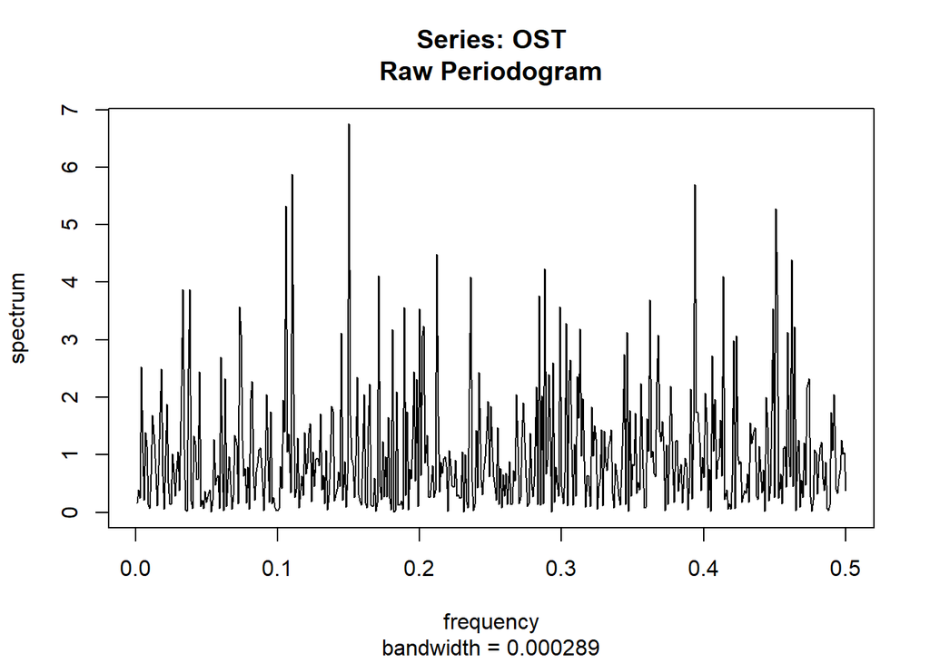

```r
spec.pgram(OST, detrend="TRUE",  log = "no",  plot = TRUE)
```

График автокорреляций:

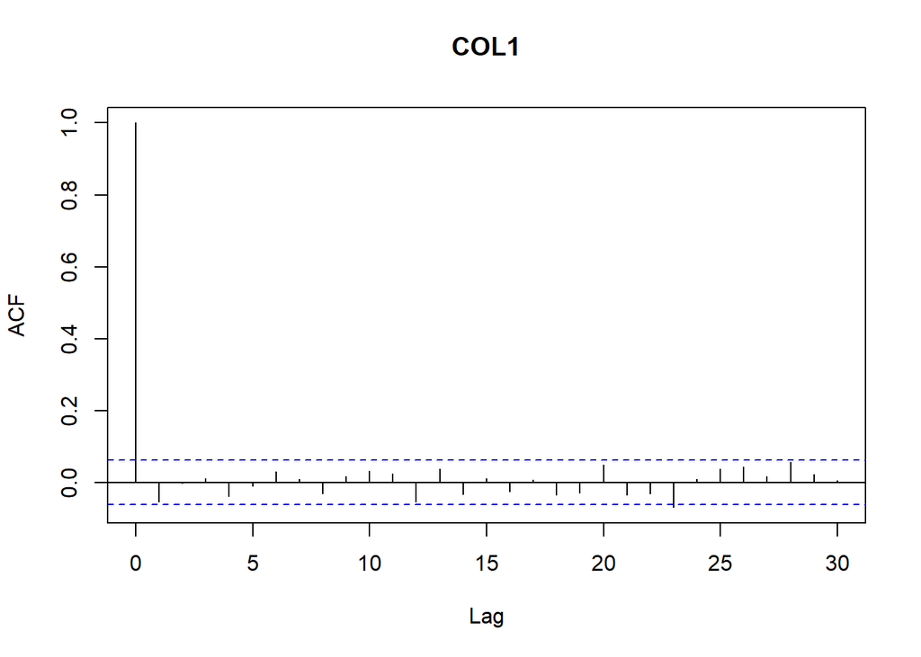

```r
acf(OST, plot = TRUE)
```

Видим, что перед нами действительно белый шум. Значит, все хорошо, мы все правильно выделили.

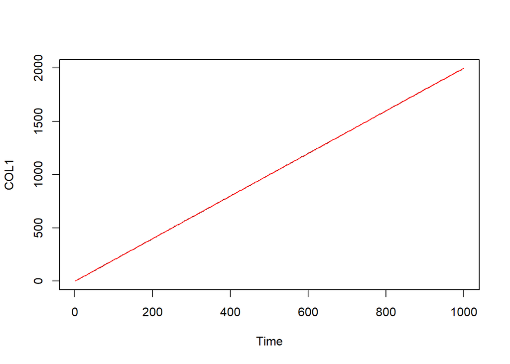

```r
TrSe <- trendrec$trend + sesrec$season

plot(ts(Mod1), col="black")
lines(TrSe ,col="red")
```

## Ряд 7

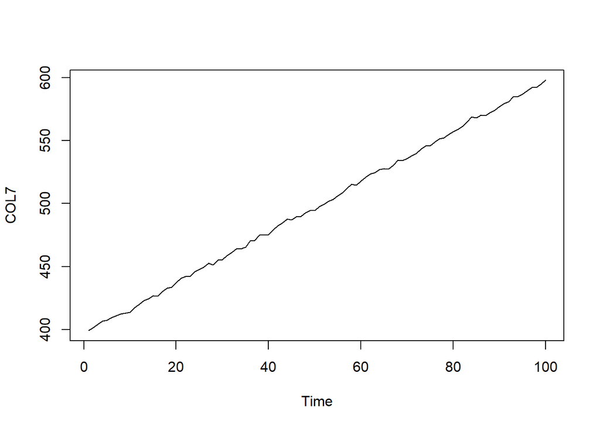

```r
Mod2 <- na.omit(data1[,2])
plot.ts(Mod2)
```

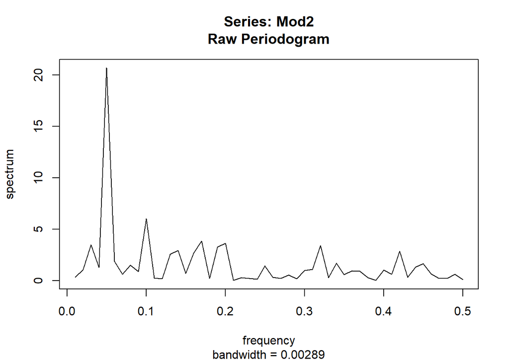

```r
spec.pgram(Mod2, detrend="TRUE",  log = "no",  plot = TRUE)
```

пик в 0.1 и явный в 0.05, а еще в других частях много…

ВФДЕЛЕНИЕ ТРЕНДА

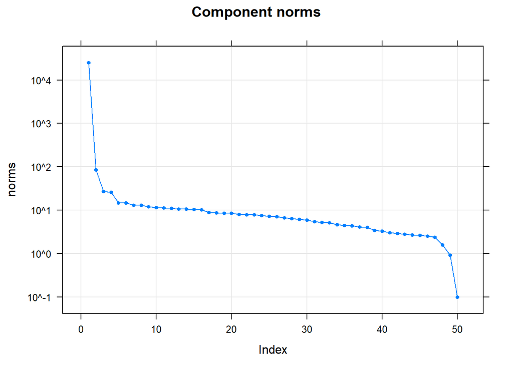

```r
s2 <- ssa(Mod2)
plot(s2) # с.ч.
```

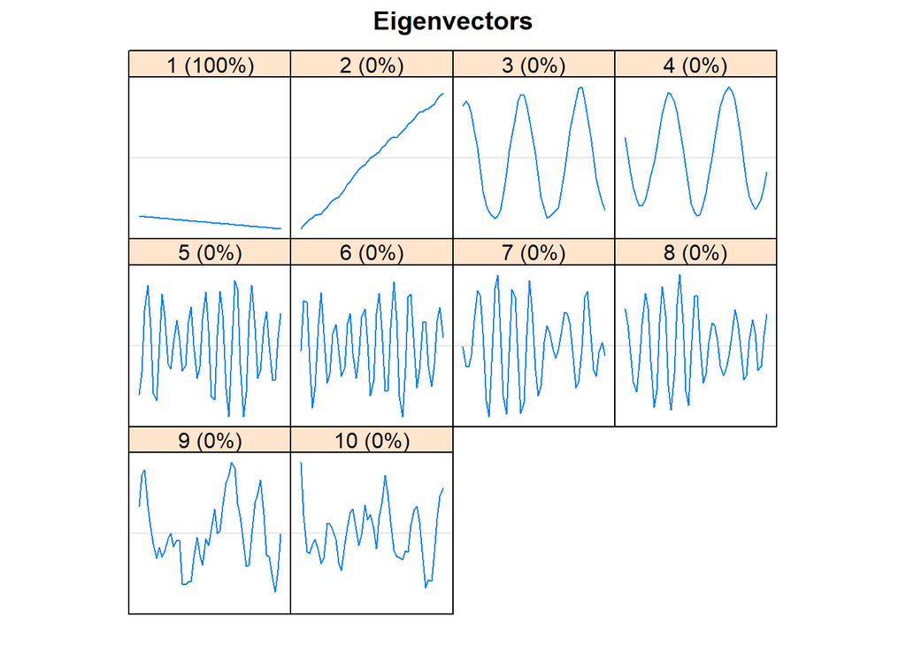

```r
plot(s2, type = "vectors")
```

2 медленно меняющие состовляющие 1 и 2я, отнесем их к тренду:

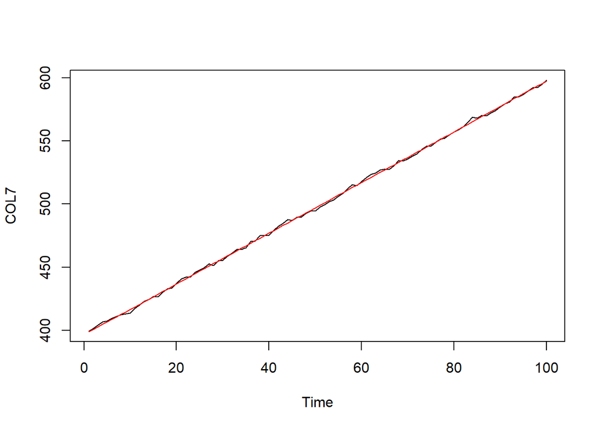

```r
trendrec2 <- reconstruct(s2, group = list(trend = c(1,2)))

plot(ts(Mod2), col="black")
lines(trendrec2$trend ,col="red")
```

ВЫДЕЛЕНИЕ ПЕРИОДИЧНОСТИ

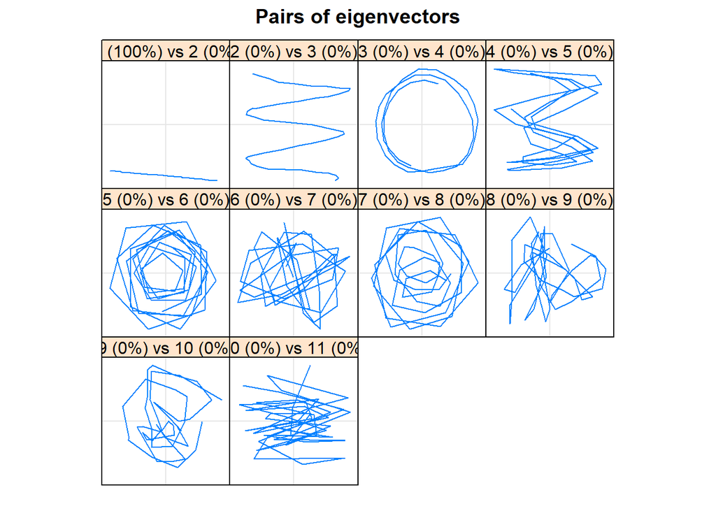

```r
plot(s2, type = "paired")
```

Посмотрев на эти графики, к сезонности попробуем отнести только 3:4 и посмотрим на остаток:

```r
pe <- parestimate(s2, groups = list(3:4))
pe
```

```
##    period     rate   |    Mod     Arg  |     Re        Im
##    19.760  -0.002878 |  0.99713   0.32 |  0.94714   0.31175
##   -19.760  -0.002878 |  0.99713  -0.32 |  0.94714  -0.31175
```

Mатрицa w-корреляций:

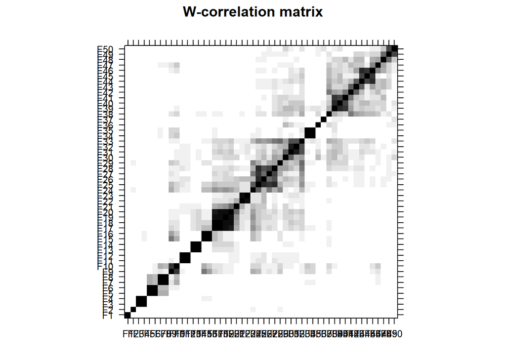

```r
sesrec2 <- reconstruct(s2, groups = list( season =c(3:4)))

plot(wcor(s2))
```

Шум:

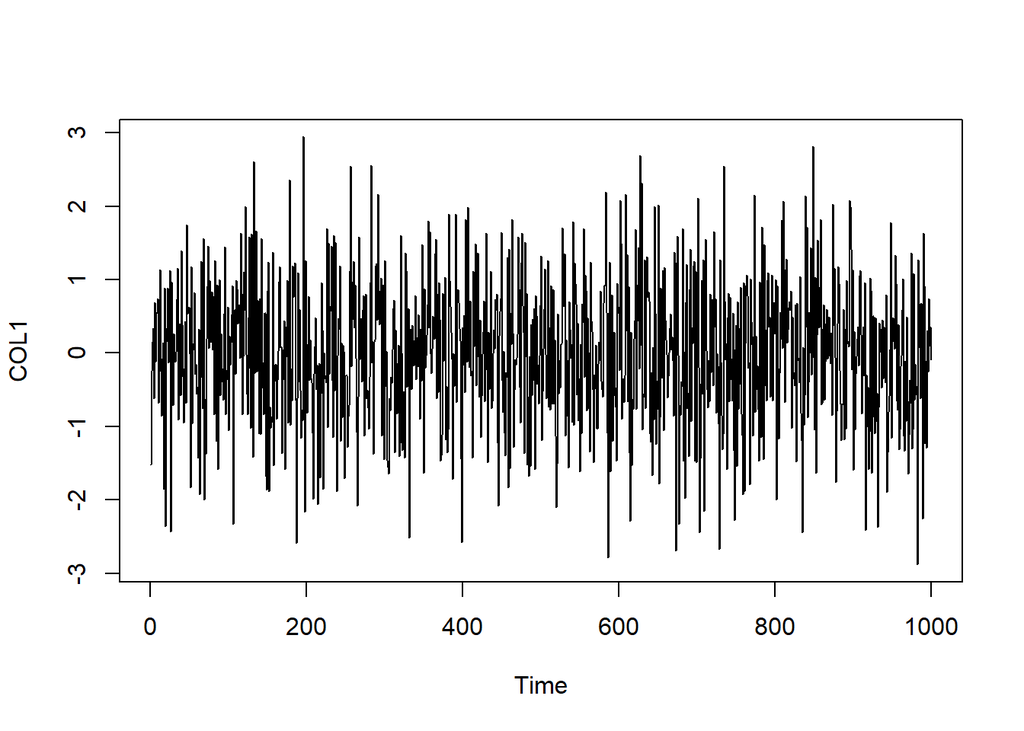

```r
OST2 <- Mod2 - trendrec2$trend - sesrec2$season
plot(ts(OST))
```

Анализ шума:

Периодограмма остатка:

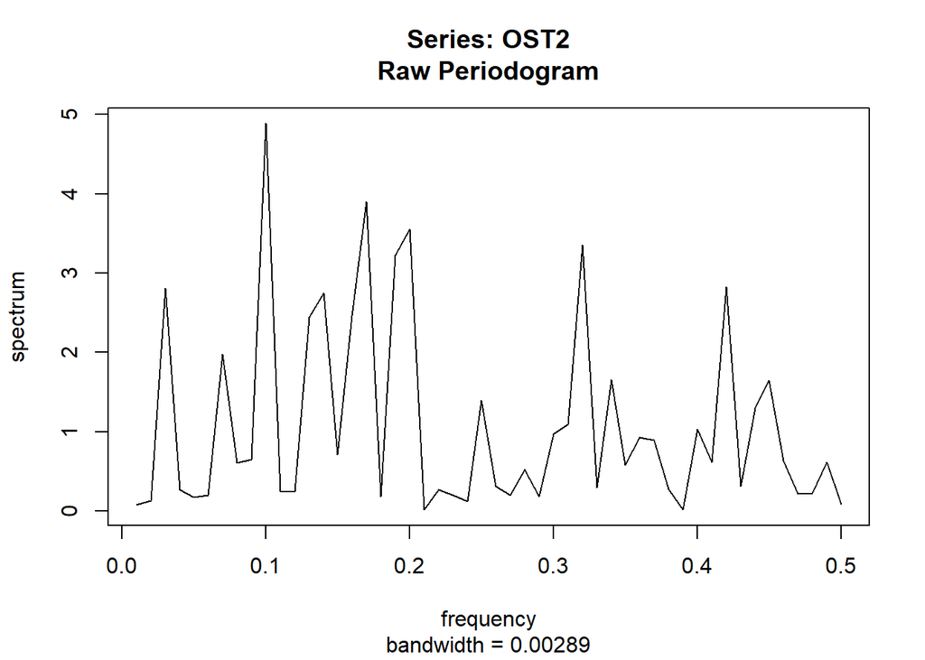

```r
spec.pgram(OST2, detrend="TRUE",  log = "no",  plot = TRUE)
```

График автокорреляций:

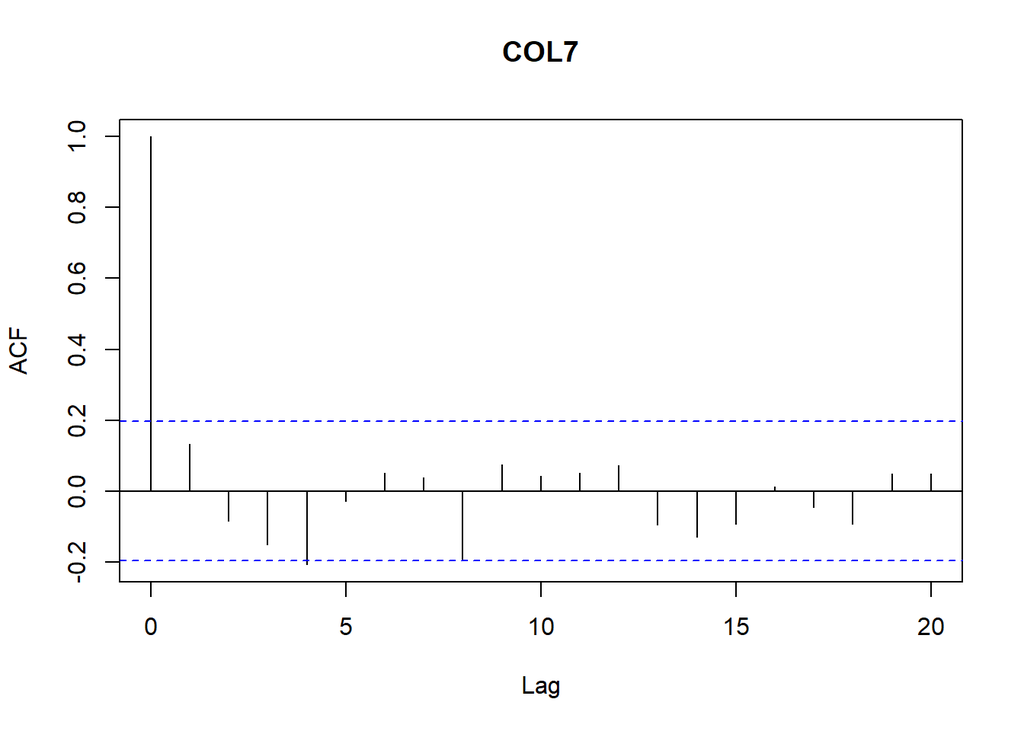

```r
acf(OST2, plot = TRUE)
```

Видим, что перед нами действительно белый шум. Значит, все хорошо, мы все правильно выделили и одно компоненты сезонности достаточно.

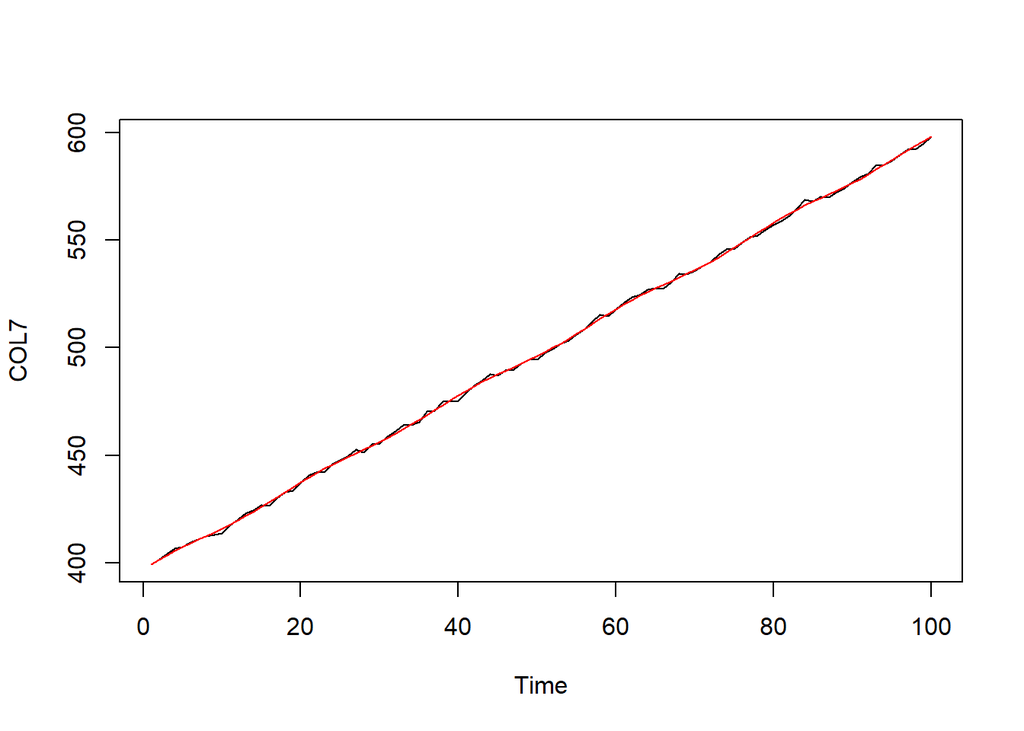

```r
TrSe2 <- trendrec2$trend + sesrec2$season

plot(ts(Mod2), col="black")
lines(TrSe2 ,col="red")
```

# SSA на реальных данных

Данные: Среднемесячная температура, 1907 - 1972 гг.

from: https://datamarket.com/data/set/22o4/mean-monthly-temperature-1907-1972#!ds=22o4&display=line

```r
data1 <- read.table('D:/Учеба/1 КУРС МАГИСТРАТУРА/Голяндина практика/mean-monthly-temperature-1907-19.csv', sep=";", header = TRUE)
head(data1)
```

```
##     Month Temp
## 1 1907-01 33,3
## 2 1907-02   46
## 3 1907-03   43
## 4 1907-04   55
## 5 1907-05 51,8
## 6 1907-06 57,5
```

График данные ряда

[figure not shown]

```r
data <- data1[,2]
dataTS <- ts(data,  frequency=12) #такая частота, т.к. данные по месяцам собраны.
plot.ts(dataTS)
```

Периодограмма

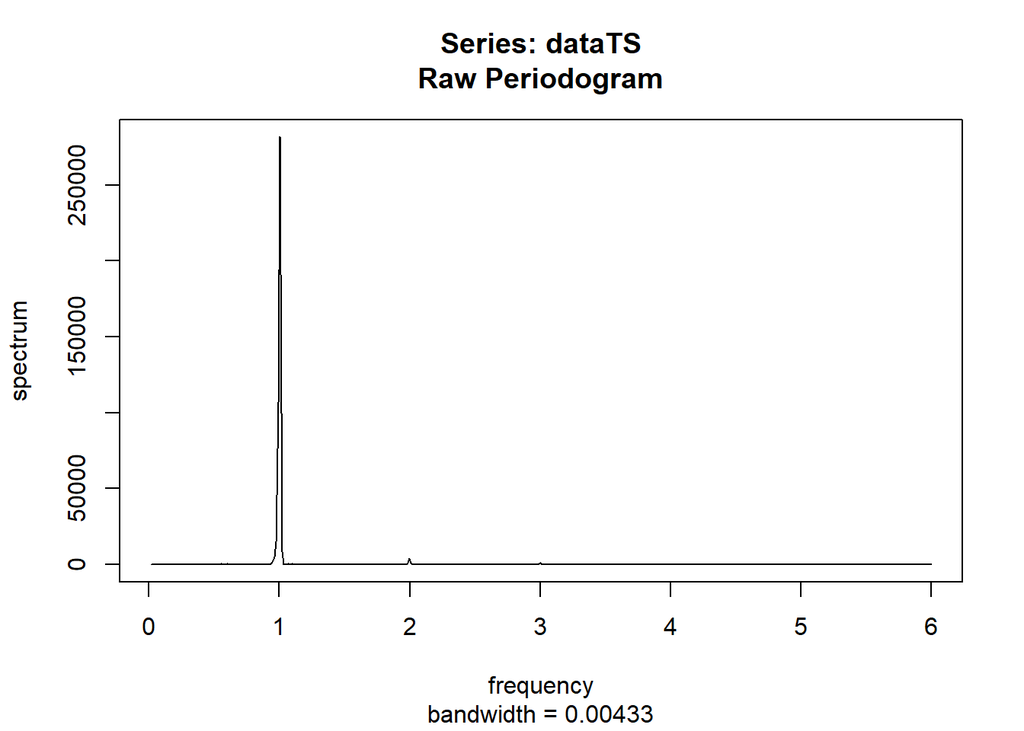

```r
SpecPGram <- spec.pgram(dataTS, detrend="True",  log = "no",  plot = TRUE)
```

Явный пик в 12, так же можно заметить пики в 6, 4 (мы увидем далее как они проявляются)

# decompose

Будем использовать встроенную функцию decompose().

## Использование:

decompose(x, type = c(“additive”, “multiplicative”), filter = NULL)

## Аргументы:

x — Временной ряд.

type — Тип сезонного компонента. Может быть сокращено.

filter — Вектор коэффициентов фильтра в обратном порядке времени (как для коэффициентов AR или MA), используется для фильтрации сезонной составляющей. Если NULL, скользящее среднее с симметричным окном выполняется.

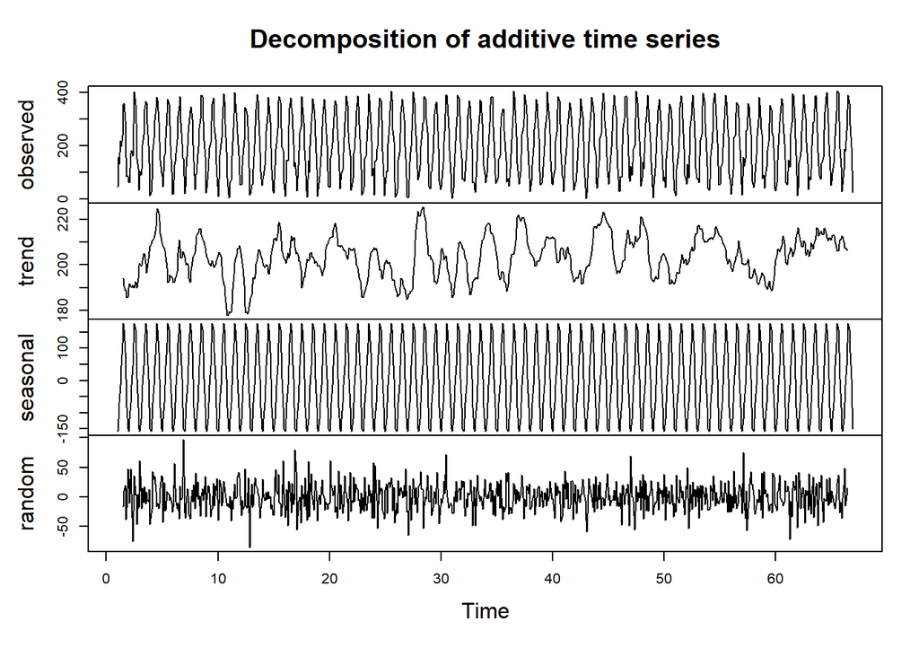

```r
dec <- stats::decompose(dataTS, "additive")
plot(dec)
```

Нарисуем тренд на графике данные ряда

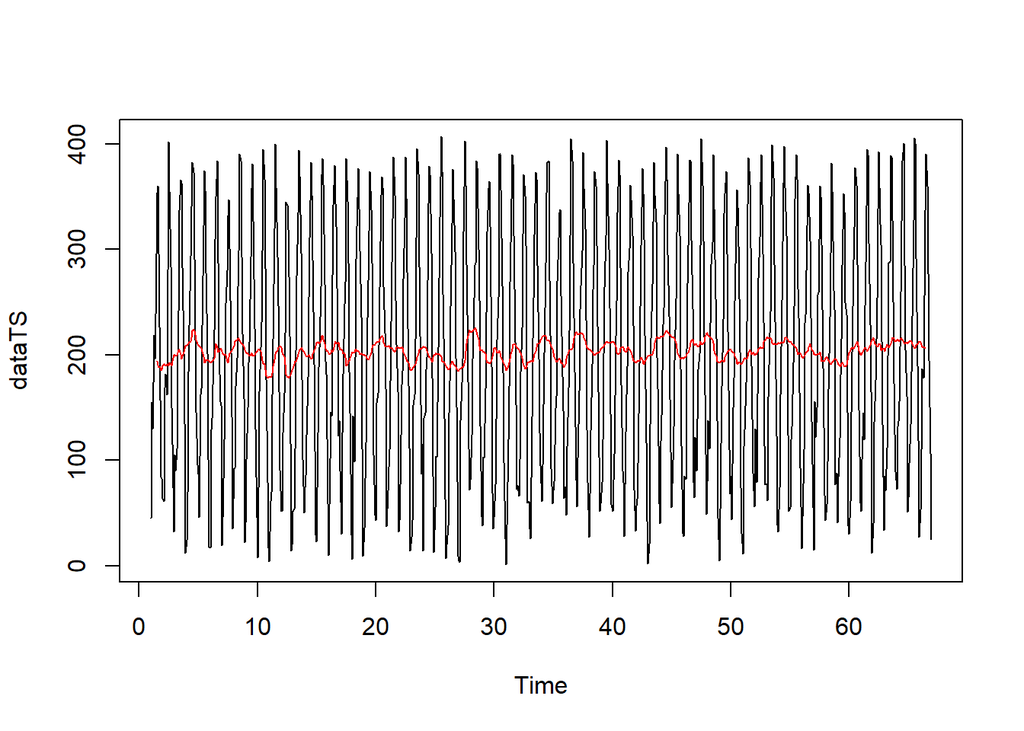

```r
plot(dataTS, col="black")
lines(dec$trend ,col="red")
```

Выделенный шум

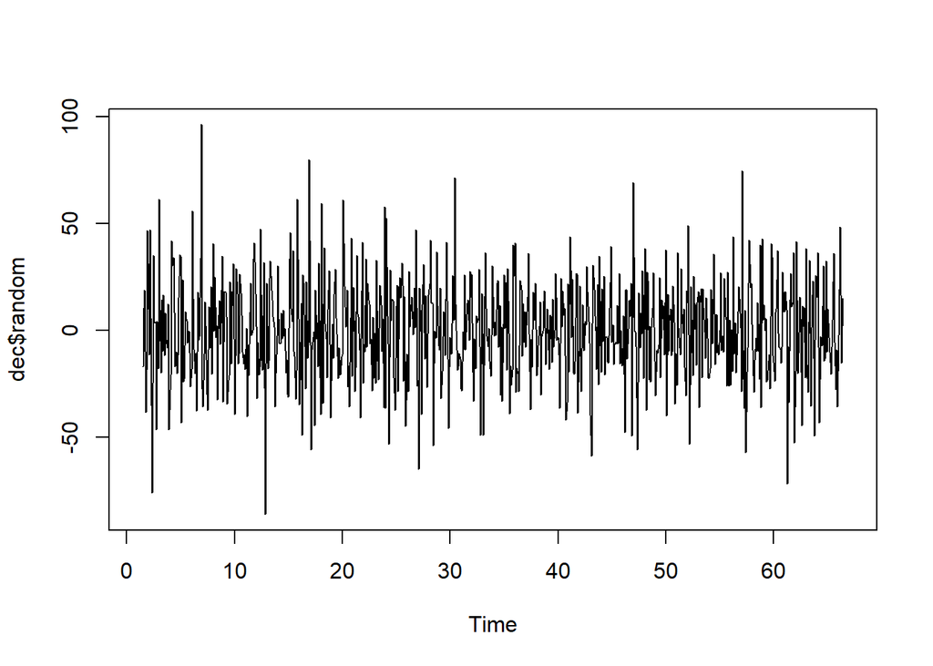

```r
plot(dec$random, col="black")
```

Периодограмма шума

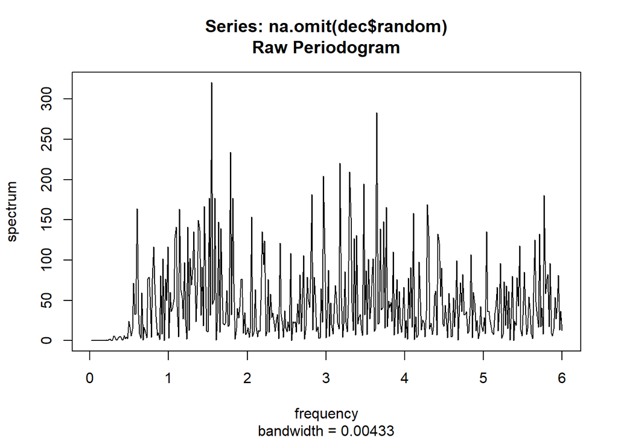

```r
SpecPGram <- spec.pgram(na.omit(dec$random), detrend="True",  log = "no",  plot = TRUE)
```

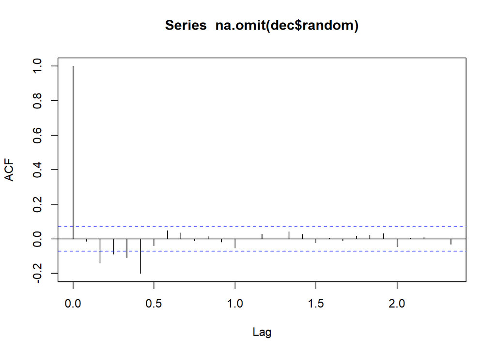

```r
acf(na.omit(dec$random))
```

По графику автокорреляций видно, что из шума забрали низкие частоты.

# stl

Будем использовать встроенную функцию stl().

## Использование:

stl(x, s.window, s.degree = 0, t.window = NULL, t.degree = 1, l.window = nextodd(period), l.degree = t.degree, s.jump = ceiling(s.window/10), t.jump = ceiling(t.window/10), l.jump = ceiling(l.window/10), robust = FALSE, inner = if(robust) 1 else 2, outer = if(robust) 15 else 0, na.action = na.fail)

## Аргументы:

x — одномерный временной ряд для разложения. Это должен быть объект класса “ts” с частотой больше единицы.

s.window — либо строка символов «периодический», либо интервал (в лагах) окна лесса для сезонного извлечения, который должен быть нечетным и не менее 7, согласно Cleveland et al. Это не имеет значения по умолчанию. (размер подрядов, по неделям, месяцам и т.д.)

s.degree — степень локально подогнанного полинома в сезонной экстракции. Должно быть ноль или один.

t.window — промежуток (в лагах) окна лесса для извлечения тренда, который должен быть нечетным. Если NULL, принимается значение по умолчанию, nextodd (потолок ((1,5 * период) / (1- (1,5 / с. Окно)))).

t.degree — степень локально подогнанного полинома в выделении трендов. Должно быть ноль или один.

l.window — диапазон (в лагах) окна лёсса фильтра нижних частот, используемого для каждой подсерии. По умолчанию используется наименьшее нечетное целое число, большее или равное частоте (x), что рекомендуется, поскольку оно предотвращает конкуренцию между трендом и сезонными компонентами. Если нечетное целое число, его заданное значение увеличивается до следующего нечетного.

l.degree — степень локально подогнанного полинома для фильтра нижних частот подсерии. Должно быть 0 или 1.

s.jump, t.jump, l.jump — целые числа, по крайней мере, один, чтобы увеличить скорость соответствующего сглаживателя. Линейная интерполяция происходит между каждым значением * .jumpth.

robust — логическое указание, будет ли использоваться надежный пример в процедуре лесса.

inner — целое число; количество «внутренних» (задних) итераций; обычно очень мало (2) итераций.

outer — целое число; количество «внешних» итераций устойчивости.

na.action — действие на пропущенные значения.

Вообще, эта функция должна бороться с проблемами в decompose (одинаковость периодов), т.к. благодаря внутреннему циклу, мы каждый раз находим новую оценку для сезонности.

Сезонная составляющая определяется лессом, сглаживающим сезонные подсерии (ряды всех значений января, …); если s.window = “periodic” — сглаживание заменяется взятием среднего. Сезонные значения удаляются, а остаток сглаживается, чтобы найти тренд. s.window управляет тем, насколько быстро может изменяться сезонный компонент. Малые значения позволяют более быстрые изменения. Установка сезонного окна равной бесконечности эквивалентна принудительному тому, чтобы сезонный компонент был периодическим (т.е. Идентичным по годам). Если мы считаем, что сезонный паттерн постоянен во времени, нам следует установить для этого параметра большое значение, чтобы использовать все данные для анализа. Если же наоборот, сезонная модель быстро развивается, уменьшить этот параметр, чтобы использовать только последние данные, чтобы на анализ не влияли старые сезонные модели, которые больше не актуальны.

В наших данных попробуем три варианта: s.window = “periodic” , 7, 37